# Costumers Data Analysis

Karim Mezhoud

12/17/2018

## Transactions list

```r
#library(plyr)

transaction_list_costumer <- plyr::ddply(basket,c("Member_number","Date"),
                                function(df1)paste(df1$itemDescription,
                                                   collapse = ","))
colnames(transaction_list_costumer) <- c("Member_number","Date","Baskets")
transaction_list_costumer
```

| Member_number | Date | Baskets |
| --- | --- | --- |
| 1000 | 15-03-2015 | sausage,whole milk,semi-finished bread,yogurt |
| 1000 | 24-06-2014 | whole milk,pastry,salty snack |
| 1000 | 24-07-2015 | canned beer,misc. beverages |
| 1000 | 25-11-2015 | sausage,hygiene articles |
| 1000 | 27-05-2015 | soda,pickled vegetables |
| 1001 | 02-05-2015 | frankfurter,curd |
| 1001 | 07-02-2014 | sausage,whole milk,rolls/buns |
| 1001 | 12-12-2014 | whole milk,soda |
| 1001 | 14-04-2015 | beef,white bread |
| 1001 | 20-01-2015 | frankfurter,soda,whipped/sour cream |

[output cut: 9990 more lines]

## How many members? and How many items?

```r
library(dplyr)
# How many member
base::table(basket$Member_number) %>% length()
```

```
## [1] 3898
```

```r
# 3898

# How many items
base::table(basket$itemDescription) %>% length()
```

```
## [1] 167
```

```r
# 167
```

## Ranking the most important Customers by the number of transactions

```r
library(dplyr)
# How many transactions by Member, the data will be arranged by descending
basket %>% group_by(Member_number) %>%
  arrange(Member_number) %>%
  dplyr::summarise(N_operation=n()) %>%
  arrange(desc(N_operation))
```

| Member_number | N_operation |
| --- | --- |
| 3180 | 36 |
| 2051 | 33 |
| 3050 | 33 |
| 3737 | 33 |
| 2271 | 31 |
| 2433 | 31 |
| 2625 | 31 |
| 3915 | 31 |
| 3872 | 30 |
| 2394 | 29 |

[output cut: 3888 more lines]

## The 10 most important customers are:

```r
Costumers_10 <- basket %>% group_by(Member_number) %>%
  arrange(Member_number) %>%
  dplyr::summarise(N_operation=n()) %>%
  arrange(desc(N_operation)) %>%
  head(10) %>%
  tibble::as.tibble()
Costumers_10
```

| Member_number | N_operation |
| --- | --- |
| 3180 | 36 |
| 2051 | 33 |
| 3050 | 33 |
| 3737 | 33 |
| 2271 | 31 |
| 2433 | 31 |
| 2625 | 31 |
| 3915 | 31 |
| 3872 | 30 |
| 2394 | 29 |

```r
target <- c("3180", "2015", "3050", "3737", "2271", "2433", "2625", "3915", "3872", "2394")
transaction_list_costumer_10 <- transaction_list_costumer %>%
  filter( Member_number %in% target)
transaction_list_costumer_10
```

| Member_number | Date | Baskets |
| --- | --- | --- |
| 2015 | 04-08-2014 | tropical fruit,soda |
| 2015 | 12-05-2015 | pork,rum |
| 2271 | 02-01-2015 | rolls/buns,mayonnaise |
| 2271 | 03-02-2014 | root vegetables,processed cheese,yogurt |
| 2271 | 04-08-2015 | other vegetables,whole milk,rolls/buns,other vegetables,bottled water,whole milk,yogurt,other vegetables |
| 2271 | 07-08-2014 | root vegetables,pickled vegetables |
| 2271 | 16-06-2015 | frankfurter,whole milk,instant coffee,bottled water |
| 2271 | 16-07-2014 | chicken,coffee |
| 2271 | 17-01-2015 | dog food,white bread |
| 2271 | 20-11-2015 | whole milk,root vegetables |

[output cut: 80 more lines]

# get the baskets of the 10 most important costumers

```r
#set column Member_number of dataframe transaction_list
transaction_list_costumer_10$Member_number <- NULL
#set column Date of dataframe transaction_list
transaction_list_costumer_10$Date <- NULL
#Rename column to Baskets
colnames(transaction_list_costumer_10) <- c("Baskets")
#Show Dataframe transactionData
transaction_list_costumer_10
```

| Baskets |
| --- |
| tropical fruit,soda |
| pork,rum |
| rolls/buns,mayonnaise |
| root vegetables,processed cheese,yogurt |
| other vegetables,whole milk,rolls/buns,other vegetables,bottled water,whole milk,yogurt,other vegetables |
| root vegetables,pickled vegetables |
| frankfurter,whole milk,instant coffee,bottled water |
| chicken,coffee |
| dog food,white bread |
| whole milk,root vegetables |

[output cut: 80 more lines]

```r
library(arules)
# Write the Baskets list to a file
write.csv(transaction_list_costumer_10,"transactions_list_costumer_10.csv", quote = FALSE, row.names = TRUE)
# load the Baskets list as a basket format using arules package
tr_list_costumer_10 <- read.transactions('transactions_list_costumer_10.csv', format = 'basket', sep=',')
tr_list_costumer_10
```

```
## transactions in sparse format with
##  91 transactions (rows) and
##  168 items (columns)
```

## Summary of the Baskets of the 10 most imortant costumers

```r
summary(tr_list_costumer_10)
```

```
## transactions as itemMatrix in sparse format with
##  91 rows (elements/itemsets/transactions) and
##  168 columns (items) and a density of 0.0242674
##
## most frequent items:
##       whole milk other vegetables           yogurt       rolls/buns
##               25               14               14               11
##             soda          (Other)
##               11              296
##
## element (itemset/transaction) length distribution:
## sizes
##  1  3  4  5  6  7  8  9 10
##  1 50 15 12  3  4  1  4  1
##
##    Min. 1st Qu.  Median    Mean 3rd Qu.    Max.
##   1.000   3.000   3.000   4.077   5.000  10.000
##
## includes extended item information - examples:
##   labels
## 1      1
## 2     10
## 3     11
```

The summary shows that the baskets with **3** items are the most frequent: **50** transactions.

## The most 10 important items for the most 10 important costumers

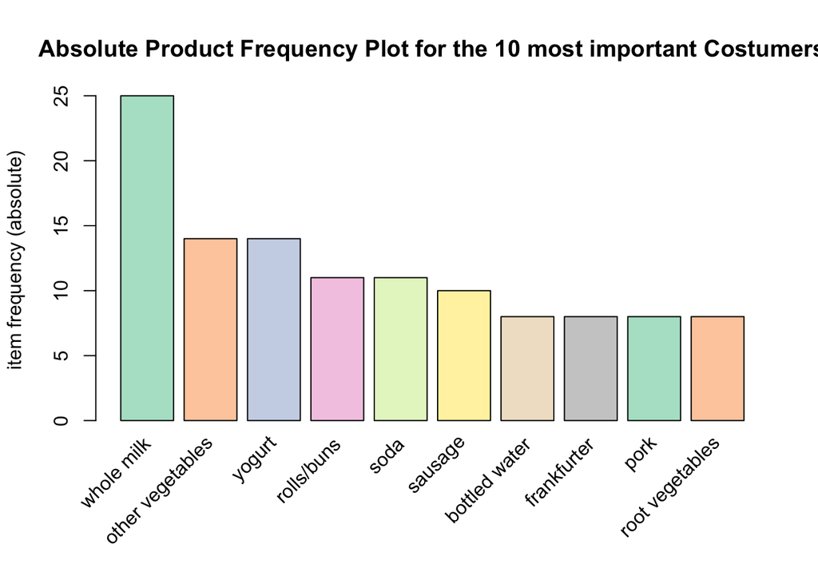

```r
library(RColorBrewer)
#par(mfrow=c(2,1))
arules::itemFrequencyPlot(tr_list_costumer_10,topN=10,type="absolute",col=brewer.pal(8,'Pastel2'), main="Absolute Product Frequency Plot for the 10 most important Costumers")
```

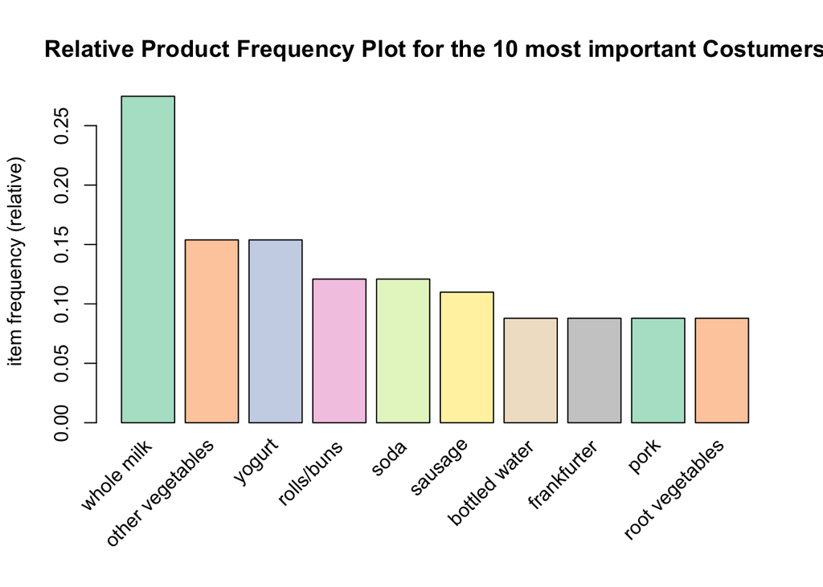

```r
arules::itemFrequencyPlot(tr_list_costumer_10,topN=10,type="relative",col=brewer.pal(8,'Pastel2'), main="Relative Product Frequency Plot for the 10 most important Costumers")
```

## Apply `Arules` algothimes to predict Rules that associate items

```r
#Min Support as 0.0001, confidence as 0.9 and maximum of 3 (where ther the most number of transaction (itemset/transaction)) products.
association.rules_Costumer_10 <- arules::apriori(tr_list_costumer_10, parameter = list(supp=0.0001, conf=0.9, maxlen=10))
```

```
## Apriori
##
## Parameter specification:
##  confidence minval smax arem  aval originalSupport maxtime support minlen
##         0.9    0.1    1 none FALSE            TRUE       5   1e-04      1
##  maxlen target   ext
##      10  rules FALSE
##
## Algorithmic control:
##  filter tree heap memopt load sort verbose
##     0.1 TRUE TRUE  FALSE TRUE    2    TRUE
##
## Absolute minimum support count: 0
##
## set item appearances ...[0 item(s)] done [0.00s].
## set transactions ...[168 item(s), 91 transaction(s)] done [0.00s].
## sorting and recoding items ... [168 item(s)] done [0.00s].
## creating transaction tree ... done [0.00s].
## checking subsets of size 1 2 3 4 5 6 7 8 9 10 done [0.00s].
## writing ... [17690 rule(s)] done [0.00s].
## creating S4 object  ... done [0.00s].
```

## Summary of the Rules of the 10 most important items specific to the 10 most important costumers

```r
# summary rules of min Support as 0.0001, confidence as 0.8 and maximum of 10 products.
summary(association.rules_Costumer_10)
```

```
## set of 17690 rules
##
## rule length distribution (lhs + rhs):sizes
##    2    3    4    5    6    7    8    9   10
##  393 2264 4059 4620 3630 1932  656  126   10
##
##    Min. 1st Qu.  Median    Mean 3rd Qu.    Max.
##   2.000   4.000   5.000   5.014   6.000  10.000
##
## summary of quality measures:
##     support          confidence      lift            count
##  Min.   :0.01099   Min.   :1    Min.   : 3.640   Min.   :1.000
##  1st Qu.:0.01099   1st Qu.:1    1st Qu.: 8.273   1st Qu.:1.000
##  Median :0.01099   Median :1    Median :22.750   Median :1.000
##  Mean   :0.01100   Mean   :1    Mean   :33.060   Mean   :1.001
##  3rd Qu.:0.01099   3rd Qu.:1    3rd Qu.:45.500   3rd Qu.:1.000
##  Max.   :0.02198   Max.   :1    Max.   :91.000   Max.   :2.000
##
## mining info:
##                 data ntransactions support confidence
##  tr_list_costumer_10            91   1e-04        0.9
```

## Inspect the association of the rules

```r
inspect(association.rules_Costumer_10[1:15])
```

```
##      lhs     rhs                support    confidence lift      count
## [1]  {53} => {ham}              0.01098901 1          45.500000 1
## [2]  {53} => {sugar}            0.01098901 1          30.333333 1
## [3]  {52} => {zwieback}         0.01098901 1          45.500000 1
## [4]  {52} => {tropical fruit}   0.01098901 1          18.200000 1
## [5]  {50} => {other vegetables} 0.01098901 1           6.500000 1
## [6]  {50} => {rolls/buns}       0.01098901 1           8.272727 1
## [7]  {46} => {butter}           0.01098901 1          30.333333 1
## [8]  {46} => {waffles}          0.01098901 1          30.333333 1
## [9]  {43} => {yogurt}           0.01098901 1           6.500000 1
## [10] {43} => {whole milk}       0.01098901 1           3.640000 1
## [11] {41} => {dessert}          0.01098901 1          22.750000 1
## [12] {41} => {root vegetables}  0.01098901 1          11.375000 1
## [13] {40} => {pork}             0.01098901 1          11.375000 1
## [14] {40} => {whole milk}       0.01098901 1           3.640000 1
## [15] {38} => {bottled water}    0.01098901 1          11.375000 1
```

- The inspection shows that the most 10 important costumers got transactions with small basket mainly with 3 items.
- There is no a complexe association between the 10 most important items.
- The costumers bougth directly, mainly 3 items whitout running through supermarket department.

```
## To reduce overplotting, jitter is added! Use jitter = 0 to prevent jitter.
```

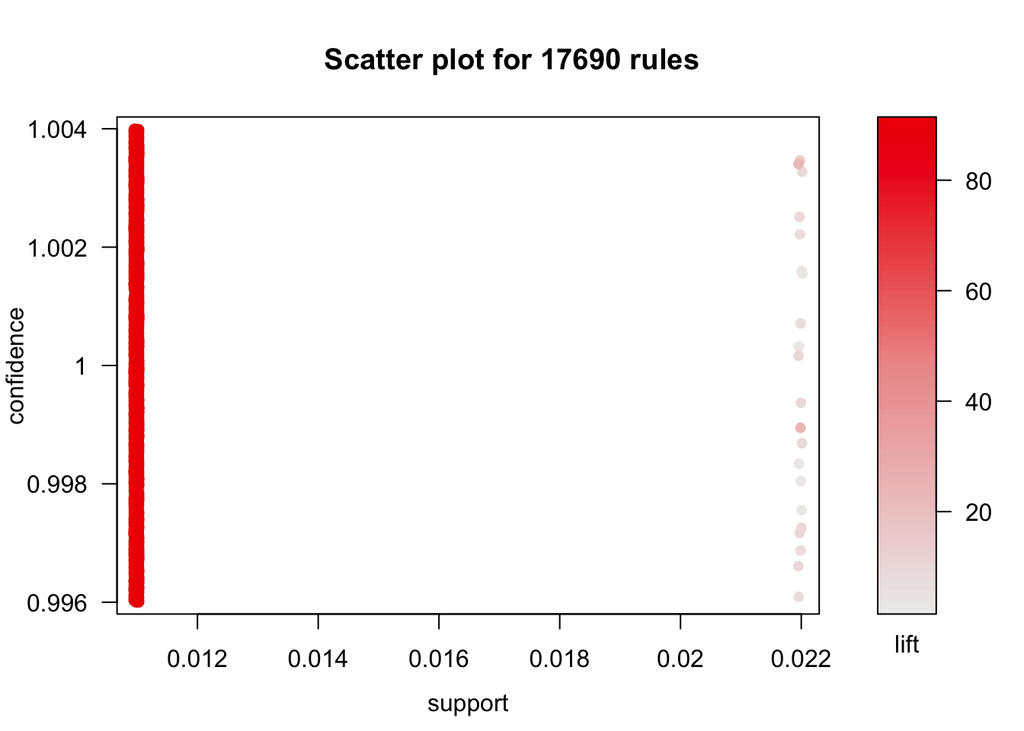

```r
library(arulesViz)
# Filter rules with confidence greater than 0.4 or 40%
subRules_costumer_10<-association.rules_Costumer_10[quality(association.rules_Costumer_10)$confidence>0.4]
#Plot SubRules
plot(subRules_costumer_10)
```

```
## To reduce overplotting, jitter is added! Use jitter = 0 to prevent jitter.
```

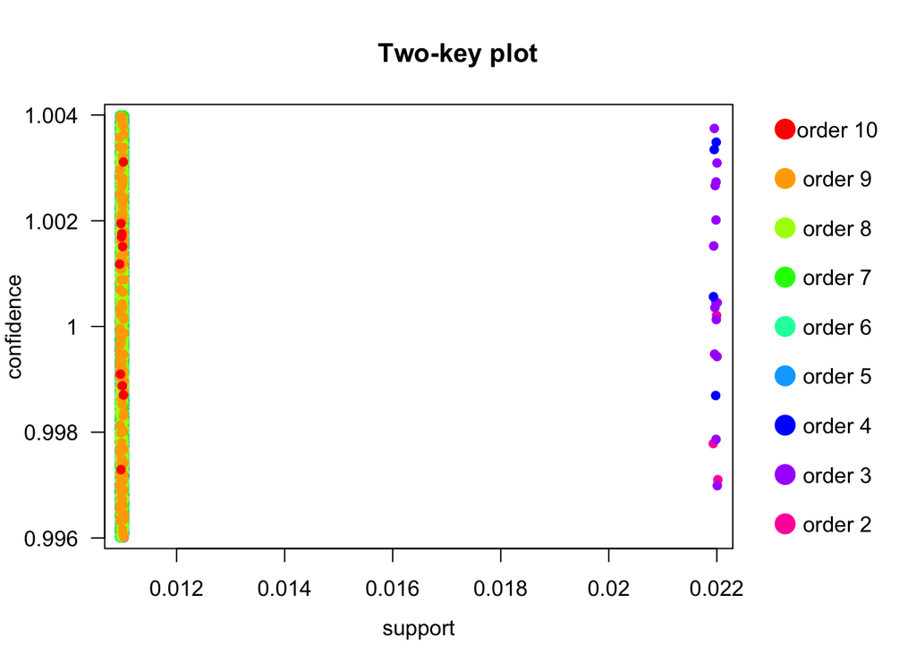

```r
plot(subRules_costumer_10,method="two-key plot")
```

- This plot shows that the most frequent fraction of transactions that contain 3 or 4 items (purple, blue) (support).

## Interactive visualisation of the Rules of the most 10 important items for the best 1O costumers

```r
#top10subRules_costumer_10 <- head(subRules_costumer_10, n = 16, by = "confidence")
plot(subRules_costumer_10[1:20], method = "graph",  engine = "htmlwidget")
```

[interactive chart not shown]

**Interpretation**

- The inspection shows that the most 10 important costumers got transactions with small basket mainly with 3 items.
- There is no a complexe association between the 10 most important items.
- The costumers bougth directly, mainly 3 items whitout running through supermarket department.

# Individual Rule Representation

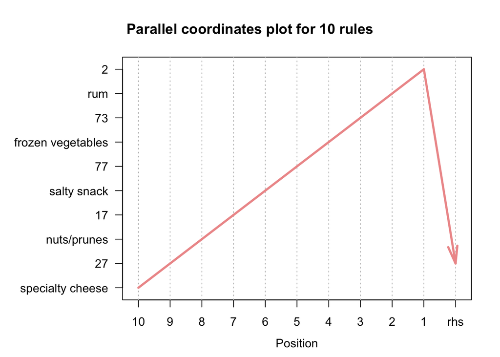

```r
# Filter top 10 rules with highest lift
subRules2_costumer_10<-head(subRules_costumer_10, n=10, by="lift")
plot(subRules2_costumer_10, method="paracoord") #, control = list(reorder = TRUE))
```

** Interpretation$**

- There is not particular significant rule for the 10 most important costumers.
- The 10 most important costumers buy small basket (3 or 4 items) without running through supermarket department